# Generalized Linear Models (GLMs)

```python
#import dump
import pandas as pd
import numpy as np
import matplotlib.pyplot as plt
import seaborn as sns

# import packages for splitting data and running linear regression
from sklearn.model_selection import train_test_split # For splitting the data into training/test datasets
import statsmodels.api as sm # For linear regression modeling/GLMs
from statsmodels.formula.api import glm
from statsmodels.formula.api import ols,logit, probit, poisson

import warnings
warnings.filterwarnings('ignore')
```

```python
#reading in Cleaned data from Catherine's part
df = pd.read_csv('cleaned_tornado.csv')
#df.head()
df.tail()
```

|  | Year | Month | Day | Date | State | Magnitude | Injuries | Fatalities | StartingLatitude | StartingLatitude.1 | EndingLatitude | EndingLongitude | Length | Width |
| --- | --- | --- | --- | --- | --- | --- | --- | --- | --- | --- | --- | --- | --- | --- |
| 67553 | 2021 | 12 | 30 | 12/30/21 | GA | 1 | 0 | 0 | 31.1703 | -83.3804 | 31.1805 | -83.3453 | 2.19 | 150 |
| 67554 | 2021 | 12 | 30 | 12/30/21 | GA | 1 | 0 | 0 | 31.6900 | -82.7300 | 31.7439 | -82.5412 | 11.71 | 300 |
| 67555 | 2021 | 12 | 31 | 12/31/21 | AL | 1 | 0 | 0 | 34.2875 | -85.7878 | 34.2998 | -85.7805 | 0.95 | 50 |
| 67556 | 2021 | 12 | 31 | 12/31/21 | GA | 1 | 0 | 0 | 33.7372 | -84.9998 | 33.7625 | -84.9633 | 2.75 | 150 |
| 67557 | 2021 | 12 | 31 | 12/31/21 | GA | 1 | 6 | 0 | 33.5676 | -83.9877 | 33.5842 | -83.9498 | 2.50 | 75 |

```python
#renaming column
df.rename(columns={'StartingLatitude.1': 'StartingLongitude'}, inplace=True)
df.tail()
```

|  | Year | Month | Day | Date | State | Magnitude | Injuries | Fatalities | StartingLatitude | StartingLongitude | EndingLatitude | EndingLongitude | Length | Width |
| --- | --- | --- | --- | --- | --- | --- | --- | --- | --- | --- | --- | --- | --- | --- |
| 67553 | 2021 | 12 | 30 | 12/30/21 | GA | 1 | 0 | 0 | 31.1703 | -83.3804 | 31.1805 | -83.3453 | 2.19 | 150 |
| 67554 | 2021 | 12 | 30 | 12/30/21 | GA | 1 | 0 | 0 | 31.6900 | -82.7300 | 31.7439 | -82.5412 | 11.71 | 300 |
| 67555 | 2021 | 12 | 31 | 12/31/21 | AL | 1 | 0 | 0 | 34.2875 | -85.7878 | 34.2998 | -85.7805 | 0.95 | 50 |
| 67556 | 2021 | 12 | 31 | 12/31/21 | GA | 1 | 0 | 0 | 33.7372 | -84.9998 | 33.7625 | -84.9633 | 2.75 | 150 |
| 67557 | 2021 | 12 | 31 | 12/31/21 | GA | 1 | 6 | 0 | 33.5676 | -83.9877 | 33.5842 | -83.9498 | 2.50 | 75 |

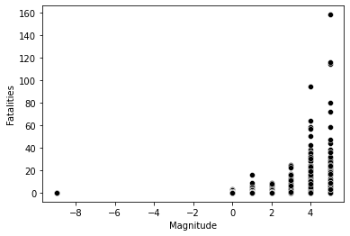

```python
sns.scatterplot(x='Magnitude', y='Fatalities', data=df, color='black')
```

We are removing rows where magnitude is -9 (this indicates no magnitude was recorded for that tornado)

```python
df = df[df['Magnitude'] != -9]
```

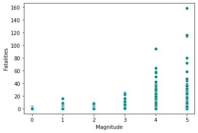

```python
sns.scatterplot(x='Magnitude', y='Fatalities', data=df, color='teal')
```

We are going to only use the data since 2007 becuase that is when the magnitude rating system changed from F rating to EF rating which is currentyl still in use today. Therefore that is the only data we are interested in for this model.

```python
# Split the df based on 'Year'
condition = df['Year'] <= 2006  # Define the condition
df_older = df[condition]  # Select rows that meet the condition

df = df[~condition]  # Select rows that do not meet the condition

#df_older.head()
df.head()
#df.tail()
```

|  | Year | Month | Day | Date | State | Magnitude | Injuries | Fatalities | StartingLatitude | StartingLongitude | EndingLatitude | EndingLongitude | Length | Width |
| --- | --- | --- | --- | --- | --- | --- | --- | --- | --- | --- | --- | --- | --- | --- |
| 49296 | 2007 | 1 | 4 | 1/4/07 | LA | 1 | 0 | 0 | 30.60 | -91.45 | 30.62 | -91.47 | 1.83 | 75 |
| 49297 | 2007 | 1 | 4 | 1/4/07 | LA | 1 | 15 | 2 | 29.92 | -91.80 | 30.05 | -91.73 | 15.07 | 100 |
| 49298 | 2007 | 1 | 5 | 1/5/07 | GA | 0 | 0 | 0 | 33.27 | -84.56 | 33.29 | -84.55 | 1.68 | 200 |
| 49299 | 2007 | 1 | 5 | 1/5/07 | GA | 0 | 0 | 0 | 31.32 | -82.47 | 31.34 | -82.47 | 2.00 | 100 |
| 49300 | 2007 | 1 | 5 | 1/5/07 | GA | 1 | 0 | 0 | 33.36 | -84.90 | 33.42 | -84.84 | 5.39 | 200 |

```python
df.info()
```

```
<class 'pandas.core.frame.DataFrame'>
Int64Index: 17657 entries, 49296 to 67557
Data columns (total 14 columns):
 #   Column             Non-Null Count  Dtype
---  ------             --------------  -----
 0   Year               17657 non-null  int64
 1   Month              17657 non-null  int64
 2   Day                17657 non-null  int64
 3   Date               17657 non-null  object
 4   State              17657 non-null  object
 5   Magnitude          17657 non-null  int64
 6   Injuries           17657 non-null  int64
 7   Fatalities         17657 non-null  int64
 8   StartingLatitude   17657 non-null  float64
 9   StartingLongitude  17657 non-null  float64
 10  EndingLatitude     17657 non-null  float64
 11  EndingLongitude    17657 non-null  float64
 12  Length             17657 non-null  float64
 13  Width              17657 non-null  int64
dtypes: float64(5), int64(7), object(2)
memory usage: 2.0+ MB
```

### Research Question

Can fatalities and injuries be predicted based on tornado characteristics?

Analysis method: Generalized Linear Models (GLMs) (modeling discrete, countable outcomes)

#### 1. Fatalities

```python
#looking at dependent variable
df["Fatalities"].describe()
```

```
count    17657.000000
mean         0.074701
std          1.617972
min          0.000000
25%          0.000000
50%          0.000000
75%          0.000000
max        158.000000
Name: Fatalities, dtype: float64
```

Research Question: Can fatalities and injuries be predicted based on tornado characteristics? Tornado Characteristics include:

- Magnitude
- Length - length of track (miles)
- Width - width of tornado (yards)

Columns to remove:

- Year
- Month
- Day
- Date
- State
- Injuries
- StartingLatitude
- StartingLongitude
- EndingLatitude
- EndingLongitude

```python
# List of column names to be dropped
columns_to_drop = ['Year','Month', 'Day','Date','State', 'Injuries', 'StartingLatitude','StartingLongitude','EndingLatitude','EndingLongitude']
#copying df for analysis on fatality
df_f = df.copy()
df_f.drop(columns=columns_to_drop, axis=1,inplace=True)
```

```python
df_f.head()
```

|  | Magnitude | Fatalities | Length | Width |
| --- | --- | --- | --- | --- |
| 49296 | 1 | 0 | 1.83 | 75 |
| 49297 | 1 | 2 | 15.07 | 100 |
| 49298 | 0 | 0 | 1.68 | 200 |
| 49299 | 0 | 0 | 2.00 | 100 |
| 49300 | 1 | 0 | 5.39 | 200 |

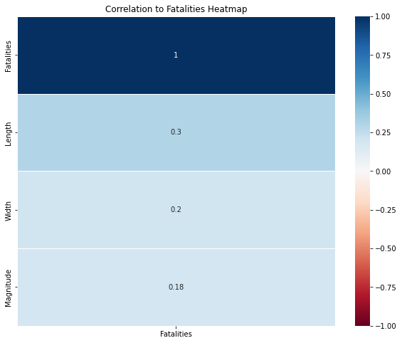

```python
#looking at correlation
corr_matrix_f = df_f.corr()

plt.figure(figsize=(10, 8))
sns.heatmap(corr_matrix_f[['Fatalities']].sort_values(by='Fatalities', ascending=False),
            annot=True,
            cmap='RdBu',
            vmin=-1,
            vmax=1,
            linewidths=0.5)
plt.title('Correlation to Fatalities Heatmap')
plt.show()
```

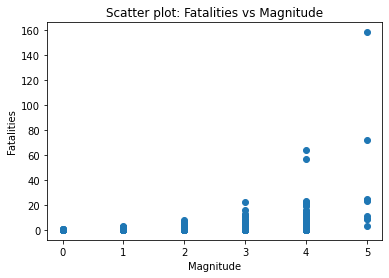

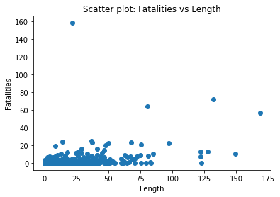

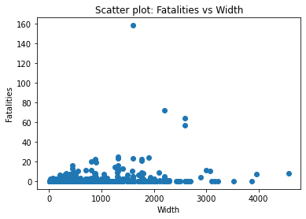

```python
y_value = 'Fatalities'  # The column to be used as y-value

# Iterate over the columns (excluding the y-value column)
for column in df_f.columns:
    if column != y_value:
        plt.scatter(df_f[column], df_f[y_value])
        plt.xlabel(column)
        plt.ylabel(y_value)
        plt.title(f"Scatter plot: {y_value} vs {column}")
        plt.show()
```

```python
#formula for model
formula_f = 'Fatalities ~ Magnitude + Length + Width'
```

```python
#creating model
cnt_model1 = glm(formula_f, data=df_f, family = sm.families.Poisson()).fit()
```

```python
#model results
cnt_model1.summary()
```

Generalized Linear Model Regression Results

| Dep. Variable: | Fatalities | No. Observations: | 17657 |
| --- | --- | --- | --- |
| Model: | GLM | Df Residuals: | 17653 |
| Model Family: | Poisson | Df Model: | 3 |
| Link Function: | Log | Scale: | 1.0000 |
| Method: | IRLS | Log-Likelihood: | -2159.0 |
| Date: | Mon, 29 May 2023 | Deviance: | 3509.9 |
| Time: | 01:58:30 | Pearson chi2: | 1.46e+04 |
| No. Iterations: | 7 | Pseudo R-squ. (CS): | 0.4294 |
| Covariance Type: | nonrobust |  |  |

|  | coef | std err | z | P>\|z\| | [0.025 | 0.975] |
| --- | --- | --- | --- | --- | --- | --- |
| Intercept | -6.2598 | 0.088 | -70.971 | 0.000 | -6.433 | -6.087 |
| Magnitude | 1.7993 | 0.029 | 61.860 | 0.000 | 1.742 | 1.856 |
| Length | 0.0134 | 0.001 | 17.688 | 0.000 | 0.012 | 0.015 |
| Width | 0.0001 | 4.66e-05 | 2.990 | 0.003 | 4.8e-05 | 0.000 |

```python
# interpreting our coefficients - plug in the coefficient (beta)
m_coeff = round(np.exp(1.7993),4)
l_coeff = round(np.exp(0.0134),4)
w_coeff = round(np.exp(0.0001),4)

print(f'Magnitude:{m_coeff}\nLength:{l_coeff}\nWidth:{w_coeff}')
```

```
Magnitude:6.0454
Length:1.0135
Width:1.0001
```

```python
df_f2 = df_f.copy()
df_f2.head()
```

|  | Magnitude | Fatalities | Length | Width |
| --- | --- | --- | --- | --- |
| 49296 | 1 | 0 | 1.83 | 75 |
| 49297 | 1 | 2 | 15.07 | 100 |
| 49298 | 0 | 0 | 1.68 | 200 |
| 49299 | 0 | 0 | 2.00 | 100 |
| 49300 | 1 | 0 | 5.39 | 200 |

```python
def graphs(x,y,data,model):
    """able to graph regression plot on scatter plot with actual values and fitted values obtained from model"""
    data['fit_values']= model.fittedvalues
    sns.regplot(x=x, y=y, data=data, line_kws={'color':'black', 'label':'LM fit'})
    plt.title('Actual vs Fitted Plot')
    sns.scatterplot(x=x, y='fit_values', data=data, color='red', label='Poisson')
```

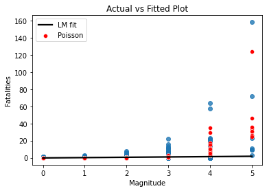

```python
graphs('Magnitude','Fatalities',df_f2,cnt_model1)
```

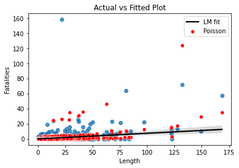

```python
graphs('Length','Fatalities',df_f2,cnt_model1)
```

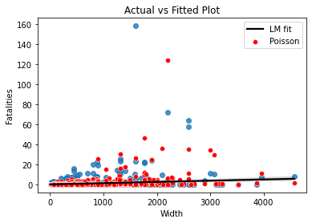

```python
graphs('Width','Fatalities',df_f2,cnt_model1)
```

**Interpretations:** interpreting the coefficients (beta) isn't as straightforward as it is with linear regression because of the multiplicative effect induced by the link function. We can compute the substantive effects by using numpy's built-in exp method.

All of these variables are statisitically significant for the model. Unsurprisingly there was a positive relationship between the magnitude of a tornado and the number of fatalities.

#### 1. Injuries

```python
#looking at dependent variable
df["Injuries"].describe()
```

```
count    17657.000000
mean         0.862378
std         16.776314
min          0.000000
25%          0.000000
50%          0.000000
75%          0.000000
max       1500.000000
Name: Injuries, dtype: float64
```

```python
# List of column names to be dropped
columns_to_drop2 = ['Year','Month', 'Day','Date','State', 'Fatalities', 'StartingLatitude','StartingLongitude','EndingLatitude','EndingLongitude']

df_i = df.copy()
df_i.drop(columns=columns_to_drop2, axis=1,inplace=True)
```

```python
df_i.head()
```

|  | Magnitude | Injuries | Length | Width |
| --- | --- | --- | --- | --- |
| 49296 | 1 | 0 | 1.83 | 75 |
| 49297 | 1 | 15 | 15.07 | 100 |
| 49298 | 0 | 0 | 1.68 | 200 |
| 49299 | 0 | 0 | 2.00 | 100 |
| 49300 | 1 | 0 | 5.39 | 200 |

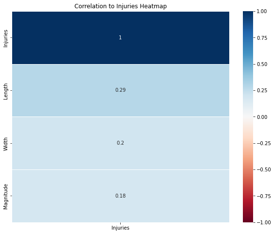

```python
#looking at correlation
corr_matrix_i = df_i.corr()

plt.figure(figsize=(10, 8))
sns.heatmap(corr_matrix_i[['Injuries']].sort_values(by='Injuries', ascending=False),
            annot=True,
            cmap='RdBu',
            vmin=-1,
            vmax=1,
            linewidths=0.5)
plt.title('Correlation to Injuries Heatmap')
plt.show()
```

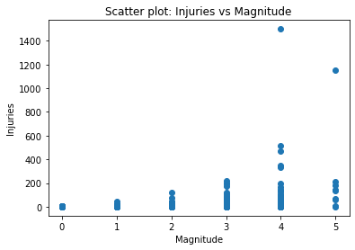

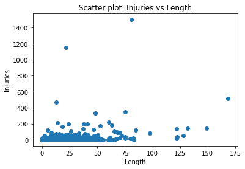

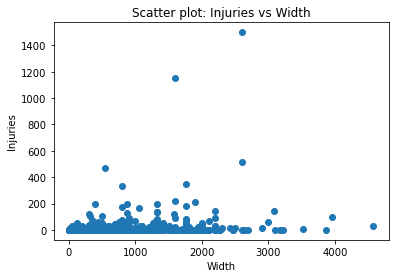

```python
y_value = 'Injuries'  # The column to be used as y-value

# Iterate over the columns (excluding the y-value column)
for column in df_i.columns:
    if column != y_value:
        plt.scatter(df_i[column], df_i[y_value])
        plt.xlabel(column)
        plt.ylabel(y_value)
        plt.title(f"Scatter plot: {y_value} vs {column}")
        plt.show()
```

```python
formula_i = 'Injuries ~ Magnitude + Length + Width'
```

```python
cnt_model2 = glm(formula_i, data=df_i, family = sm.families.Poisson()).fit()
```

```python
cnt_model2.summary()
```

Generalized Linear Model Regression Results

| Dep. Variable: | Injuries | No. Observations: | 17657 |
| --- | --- | --- | --- |
| Model: | GLM | Df Residuals: | 17653 |
| Model Family: | Poisson | Df Model: | 3 |
| Link Function: | Log | Scale: | 1.0000 |
| Method: | IRLS | Log-Likelihood: | -23365. |
| Date: | Mon, 29 May 2023 | Deviance: | 42978. |
| Time: | 02:05:49 | Pearson chi2: | 1.25e+05 |
| No. Iterations: | 7 | Pseudo R-squ. (CS): | 0.9950 |
| Covariance Type: | nonrobust |  |  |

|  | coef | std err | z | P>\|z\| | [0.025 | 0.975] |
| --- | --- | --- | --- | --- | --- | --- |
| Intercept | -3.0789 | 0.022 | -141.514 | 0.000 | -3.122 | -3.036 |
| Magnitude | 1.5565 | 0.008 | 194.461 | 0.000 | 1.541 | 1.572 |
| Length | 0.0118 | 0.000 | 49.554 | 0.000 | 0.011 | 0.012 |
| Width | 0.0003 | 1.32e-05 | 21.854 | 0.000 | 0.000 | 0.000 |

```python
# interpreting our coefficients - plug in the coefficient (beta)
m_coeff2 = round(np.exp(1.5565),4)
l_coeff2 = round(np.exp(0.0118),4)
w_coeff2 = round(np.exp(0.0003),4)

print(f'Magnitude:{m_coeff2}\nLength:{l_coeff2}\nWidth:{w_coeff2}')
```

```
Magnitude:4.7422
Length:1.0119
Width:1.0003
```

```python
df_i2 = df_i.copy()
df_i2.head()
```

|  | Magnitude | Injuries | Length | Width |
| --- | --- | --- | --- | --- |
| 49296 | 1 | 0 | 1.83 | 75 |
| 49297 | 1 | 15 | 15.07 | 100 |
| 49298 | 0 | 0 | 1.68 | 200 |
| 49299 | 0 | 0 | 2.00 | 100 |
| 49300 | 1 | 0 | 5.39 | 200 |

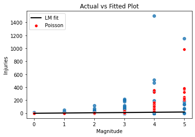

```python
graphs('Magnitude','Injuries',df_i2,cnt_model2)
```

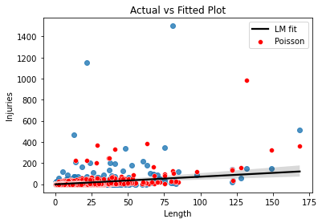

```python
graphs('Length','Injuries',df_i2,cnt_model2)
```

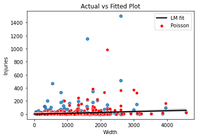

```python
graphs('Width','Injuries',df_i2,cnt_model2)
```

**Interpretations:** interpreting the coefficients (beta) isn't as straightforward as it is with linear regression because of the multiplicative effect induced by the link function. We can compute the substantive effects by using numpy's built-in exp method.

- Magnitude: For each unit increase in the Magnitude of a tornado, the predicted number of injuries is expected to multiply by approximately 4.7422 times, holding other variables constant.
- Length: For each mile increase in the Length of a tornado track, the predicted number of injuries is expected to multiply by approximately 1.0119 times.
- Width: For each yard increase in the Width of a tornado, the predicted number of injuries is expected to multiply by approximately 1.0003 times.

All of these variables are statisitically significant for the model. Unsurprisingly there was a positive relationship between the magnitude of a tornado and the number of injuries.